# Modelos de árbol de decisión

# Clustering kmeans

Otro tipo de analisis al que se venia haciendo con arboles. Busco si de alguna manera se pueden separan en poblaciones diferentes, es decir, si se pueden separar en grupos y ver que tienen en comun esos grupos

#### Importo librerías

```python
from sklearn.cluster import KMeans,DBSCAN
from scipy.cluster import hierarchy
from scipy.cluster.hierarchy import dendrogram, linkage, fcluster
from sklearn.metrics import silhouette_score,calinski_harabasz_score,classification_report,confusion_matrix
from sklearn.preprocessing import StandardScaler
from scipy.spatial.distance import pdist,squareform
```

```python
# Estandarizamos los datos
scaler=StandardScaler()
X = data_celulas[column_names]
X_sc=scaler.fit_transform(X);
```

silhouette y calinsky score es para encontrar numero óptimo de clusters

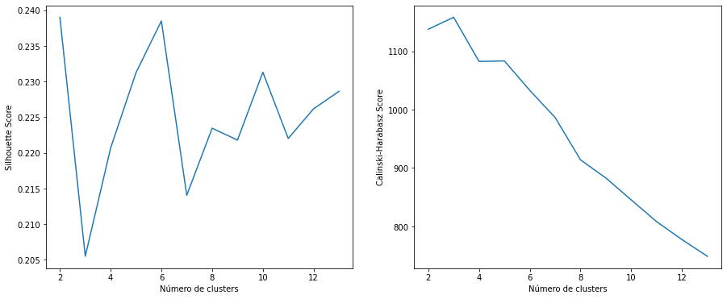

```python
evaluation = []
for k in range(2,14):
    kmeans = KMeans(n_clusters=k, random_state=0)
    kmeans.fit(X_sc)
    labels = kmeans.labels_
    centroids = kmeans.cluster_centers_
    #predY = np.choose(labels, pd.Series(range(0,k+1)).astype(np.int64))
    silhouette = silhouette_score(X_sc, labels, metric='euclidean')
    calinsky = calinski_harabasz_score(X_sc, labels)
    evaluation.append([k, silhouette, calinsky])
    #print("K= ", evaluation)

evaluation=np.array(evaluation);
f,ax=plt.subplots(1,2,figsize=(15,6))
ax[0].plot(evaluation[:,0],evaluation[:,1])
ax[0].set_ylabel('Silhouette Score')
ax[0].set_xlabel('Número de clusters')

ax[1].plot(evaluation[:,0],evaluation[:,2])
ax[1].set_ylabel('Calinski-Harabasz Score')
ax[1].set_xlabel('Número de clusters');
```

#### Pruebo predicción usando solo 2 clusters

```
              precision    recall  f1-score   support

           0       0.49      0.62      0.55      3196
           1       0.19      0.12      0.14      2343

    accuracy                           0.41      5539
   macro avg       0.34      0.37      0.35      5539
weighted avg       0.36      0.41      0.38      5539
```

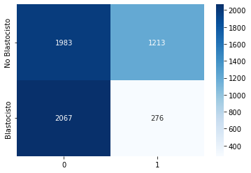

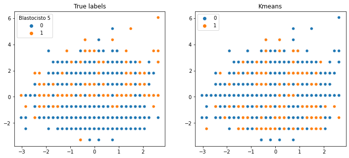

```python
# 2 Clusters
kmeans = KMeans(n_clusters=2, random_state=0)
kmeans.fit(X_sc)
labels_km = kmeans.labels_

y_true = data_celulas['Blastocisto 5']

sns.heatmap(confusion_matrix(y_true,labels_km),annot=True,cmap='Blues',fmt=".0f",yticklabels=['No Blastocisto','Blastocisto']);

print(classification_report(y_true,labels_km))

f,ax=plt.subplots(1,2,figsize=(12,5))
sns.scatterplot(X_sc[:,0],X_sc[:,1],hue=y_true,ax=ax[0])
ax[0].set_title('True labels')
sns.scatterplot(X_sc[:,0],X_sc[:,1],hue=labels_km,ax=ax[1])
ax[1].set_title('Kmeans')
```

## Otro tipo de clustering con dendograma

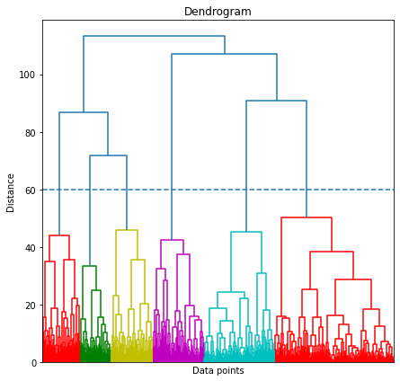

```python
Z = linkage(X_sc, 'ward');

plt.figure(figsize=[7,7])
plt.title('Dendrogram')
plt.xlabel('Data points')
plt.ylabel('Distance')

color_palette=['r','g','y','m', 'c'];

hierarchy.set_link_color_palette(color_palette)

dendrogram(
    Z,
    leaf_rotation=90.,
    leaf_font_size=5.,
    color_threshold=60,
)
plt.hlines(60,0,X_sc.shape[0]*100,linestyle='--')
plt.xticks([])
plt.show()
```

Se pueden diferenciar 6 clusters con el dendograma, ahora habria que ver que es lo que determina esos clusters y que cambia entre cada uno

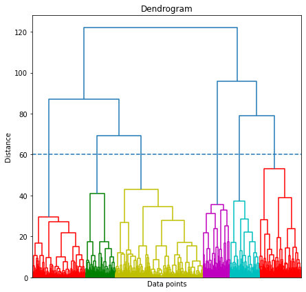

```python
column_names = ["PacienteEdad","Celulas 2", "Celulas 3", "Fragmentos 2","Fragmentos 3",'OvulosDonante', "Simetria 2","Simetria 3",]
scaler=StandardScaler()
X = data_celulas[column_names]
X_sc=scaler.fit_transform(X);

Z = linkage(X_sc, 'ward');

plt.figure(figsize=[7,7])
plt.title('Dendrogram')
plt.xlabel('Data points')
plt.ylabel('Distance')

color_palette=['r','g','y','m', 'c'];

hierarchy.set_link_color_palette(color_palette)

dendrogram(
    Z,
    leaf_rotation=90.,
    leaf_font_size=5.,
    color_threshold=60,
)
plt.hlines(60,0,X_sc.shape[0]*100,linestyle='--')
plt.xticks([])
plt.show()
```

```
Cluster labels:
 [5 5 5 ... 6 5 5]
```

[figure not shown]

```python
labels=fcluster(Z,6,criterion='maxclust');

print('Cluster labels:\n',labels)

sns.scatterplot(x=X_sc[:,0],y=X_sc[:,1],hue=labels,legend='full');
plt.xlabel('Income',fontsize=15);plt.ylabel('Spending Score',fontsize=15);
```

Cantidad de embriones por label

```python
data_celulas["labels"] = labels
pd.DataFrame(data_celulas["labels"].value_counts())
```

|  | labels |
| --- | --- |
| 6 | 1882 |
| 5 | 1106 |
| 4 | 800 |
| 3 | 671 |
| 1 | 601 |
| 2 | 479 |

```python
data_celulas.loc[data_celulas["labels"]==1]
label_1 = data_celulas.loc[data_celulas["labels"]==1]["Blastocisto 5"].value_counts()

data_celulas.loc[data_celulas["labels"]==2]
label_2 = data_celulas.loc[data_celulas["labels"]==2]["Blastocisto 5"].value_counts()

data_celulas.loc[data_celulas["labels"]==3]
label_3 = data_celulas.loc[data_celulas["labels"]==3]["Blastocisto 5"].value_counts()

data_celulas.loc[data_celulas["labels"]==4]
label_4 = data_celulas.loc[data_celulas["labels"]==4]["Blastocisto 5"].value_counts()

data_celulas.loc[data_celulas["labels"]==5]
label_5 = data_celulas.loc[data_celulas["labels"]==5]["Blastocisto 5"].value_counts()

data_celulas.loc[data_celulas["labels"]==6]
label_6 = data_celulas.loc[data_celulas["labels"]==6]["Blastocisto 5"].value_counts()
```

```python
pd.DataFrame({"label_1":label_1,"label_2":label_2,"label_3":label_3,"label_4":label_4,"label_5":label_5,"label_6":label_6})
```

|  | label_1 | label_2 | label_3 | label_4 | label_5 | label_6 |
| --- | --- | --- | --- | --- | --- | --- |
| 0 | 530 | 301 | 442 | 437 | 589 | 897 |
| 1 | 71 | 178 | 229 | 363 | 517 | 985 |

1: Blastocisto, 0:No blastocisto